# Predictive Modelling - Application to Weight Lifting Dataset

Subrata

March 2, 2017

## Introduction

Using devices such as Jawbone Up, Nike FuelBand, and Fitbit it is now possible to collect a large amount of data about personal activity relatively inexpensively. These type of devices are part of the quantified self movement - a group of enthusiasts who take measurements about themselves regularly to improve their health, to find patterns in their behavior, or because they are tech geeks. One thing that people regularly do is quantify how much of a particular activity they do, but they rarely quantify how well they do it. In this project, our goal will be to use data from accelerometers on the belt, forearm, arm, and dumbell of 6 participants.

The data for this project come from this source: http://groupware.les.inf.puc-rio.br/har.

## Basic Processing

It was mentioned by the researchers[1] that they had extracted the features using a sliding windows approach with different length from of 0.5 seconds to 2.5 seconds with 0.5 seconds overlap.In each step of the sliding window the various features were extracted.

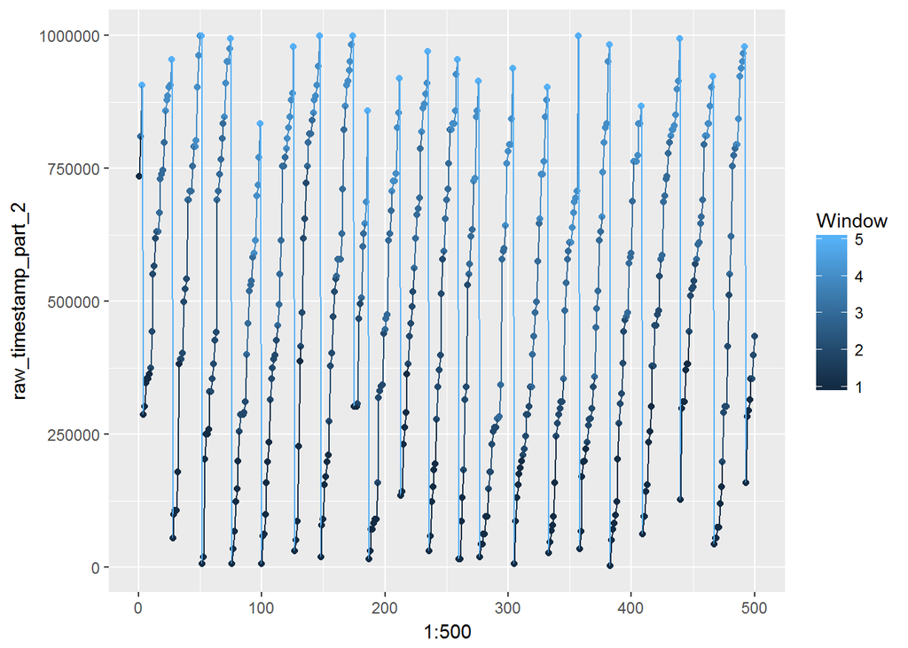

Fig 1: Plot of first 500 points for TimeStamp_2

Next, we focus on preprocessing the data.

Firstly, we divide the training data into training and testing data sets with 25% of the data set kept in the testing bucket.

Secondly, we use **nearzerovariance** technique to remove all variables with near zero variance.

Thirldy, we impute all missing data points using **k nearest neighbours imputation** technique.

Fourthly, we processed the data by **scaling and centering** to transform the training data into normalized gaussian dataset.

Fiftly, we identify all predictors that have **correlation more than 75%** and remove those from the data set.

## Training

As part of training, we firstly adopt random forest and force the algorithm to execute bagging by trying all 55 variables at each split. Bagging will also take into consideration cross validation by default as part of its algorithm.

The results are quite positive with an OOB error reported at **less than 2.5%**.

```
##
## Call:
##  randomForest(formula = classe ~ ., data = TrainingDataProcessedCorRem[,      -ncol(TrainingDataProcessedCorRem)], mtry = ncol(TrainingDataProcessedCorRem) -      2, importance = TRUE)
##                Type of random forest: classification
##                      Number of trees: 500
## No. of variables tried at each split: 55
##
##         OOB estimate of  error rate: 1.98%
## Confusion matrix:
##      A    B    C    D    E class.error
## A 4150   19    6    7    3 0.008363202
## B   45 2773   19    5    6 0.026334270
## C    2   38 2498   25    4 0.026879626
## D    4    6   61 2333    8 0.032752902
## E    0    3   11   20 2672 0.012564671
```

However, we want to further refine the model and hence we identify variables of high importance in the model.

We identified the top 20 variables that seemed important for all five classes of the classification model and re ran the random forest model on these 20 variables. We did not force the model to execute bagging this time.

The results improved with a OOB error estimate reported at **less than 1.5%**. The random forest model used 4 variables at each split out of the 20 variables, we identified.

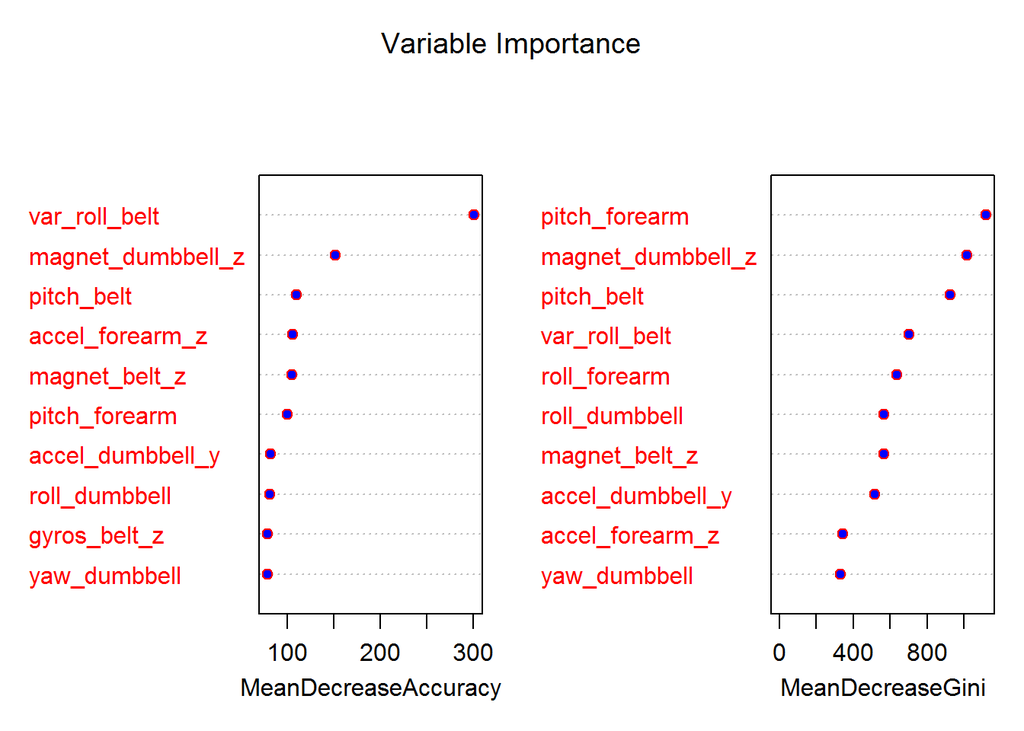

```
##
## Call:
##  randomForest(formula = form, data = TrainingDataProcessedCorRem[,      -indexwindow], importance = TRUE)
##                Type of random forest: classification
##                      Number of trees: 500
## No. of variables tried at each split: 4
##
##         OOB estimate of  error rate: 1.32%
## Confusion matrix:
##      A    B    C    D    E class.error
## A 4172    9    3    0    1 0.003106332
## B   29 2790   24    2    3 0.020365169
## C    0   35 2514   15    3 0.020646669
## D    0    1   46 2360    5 0.021558872
## E    0    0    6   13 2687 0.007021434
```

## Testing

We next apply the final model on the testing data post preprocessing the testing data.

```
## Confusion Matrix and Statistics
##
##           Reference
## Prediction    A    B    C    D    E
##          A 1387    4    0    1    0
##          B    6  940    3    0    1
##          C    1    5  847   19    2
##          D    0    0    5  783    3
##          E    1    0    0    1  895
##
## Overall Statistics
##
##                Accuracy : 0.9894
##                  95% CI : (0.9861, 0.9921)
##     No Information Rate : 0.2845
##     P-Value [Acc > NIR] : < 2.2e-16
##
##                   Kappa : 0.9866
##  Mcnemar's Test P-Value : NA
##
## Statistics by Class:
##
##                      Class: A Class: B Class: C Class: D Class: E
## Sensitivity            0.9943   0.9905   0.9906   0.9739   0.9933
## Specificity            0.9986   0.9975   0.9933   0.9980   0.9995
## Pos Pred Value         0.9964   0.9895   0.9691   0.9899   0.9978
## Neg Pred Value         0.9977   0.9977   0.9980   0.9949   0.9985
## Prevalence             0.2845   0.1935   0.1743   0.1639   0.1837
## Detection Rate         0.2828   0.1917   0.1727   0.1597   0.1825
## Detection Prevalence   0.2838   0.1937   0.1782   0.1613   0.1829
## Balanced Accuracy      0.9964   0.9940   0.9920   0.9860   0.9964
```

```
## Window 1 - Accuracy: 0.9872372
## Window 2 - Accuracy: 0.9934426
## Window 3 - Accuracy: 0.9893143
## Window 4 - Accuracy: 0.9914286
## Window 5 - Accuracy: 0.9868106
```

## Conclusion

This prediction methodology is however not scalable as there are infinite permuatations of errors that a person can commit and to predict each type of errors using this approach will need infinite training data sets on infinite permutations of exercising errors.

## Reference

1. Velloso, E.; Bulling, A.; Gellersen, H.; Ugulino, W.; Fuks, H. Qualitative Activity Recognition of Weight Lifting Exercises. Proceedings of 4th International Conference in Cooperation with SIGCHI (Augmented Human ’13) . Stuttgart, Germany: ACM SIGCHI, 2013.

Read more: http://groupware.les.inf.puc-rio.br/har#ixzz4a8FjpXvS

## Code Appendix

```r
**Libraries used**

knitr::opts_chunk$set(echo = FALSE)
suppressPackageStartupMessages(library(dplyr))
suppressPackageStartupMessages(library(caret))
suppressPackageStartupMessages(library(RANN))
suppressPackageStartupMessages(library(randomForest))

**Data download**

URL1="https://d396qusza40orc.cloudfront.net/predmachlearn/pml-training.csv"

if (!file.exists("./pml-training.csv")) {
        download.file(URL1, destfile = "./pml-training.csv")
}
Traindata<-read.csv("./pml-training.csv", stringsAsFactors = FALSE)

**Preprocessing**

Splitter<-Traindata$raw_timestamp_part_1
TrainSplit<-split(Traindata,Splitter)

mutate_func<-function(x){as.data.frame(x)%>%mutate(Window=
  ifelse(raw_timestamp_part_2<quantile(raw_timestamp_part_2)[2],1,
    ifelse(raw_timestamp_part_2<quantile(raw_timestamp_part_2)[3],2,
      ifelse(raw_timestamp_part_2<quantile(raw_timestamp_part_2)[4], 3,
        ifelse(raw_timestamp_part_2<quantile(raw_timestamp_part_2)[5],4,5)))))}

TrainSplittr<-lapply(TrainSplit,mutate_func)


TraindataMod<-as.data.frame(NULL)
for( i in 1:length(TrainSplittr)){
  x<-as.data.frame(TrainSplittr[[i]])
  TraindataMod<-rbind(TraindataMod,x)
}


intrain<-createDataPartition(y=TraindataMod$classe,p=.75,list=FALSE)
Training<-TraindataMod[intrain,]
Testing<-TraindataMod[-intrain,]

TrainingData<-Training[,-c(1,2,3,4,5,6,7)]
indexclasse<-grep("classe",names(TrainingData))
indexwindow<-grep("Window",names(TrainingData))

TrainingData<-TrainingData[,-nearZeroVar(TrainingData[,-c(indexclasse,indexwindow)])]

set.seed(12342)
indexclasse<-grep("classe",names(TrainingData))
indexwindow<-grep("Window",names(TrainingData))

PreProc<-preProcess(TrainingData[,-c(indexclasse,indexwindow)],method=c("center","scale","knnImpute"))
TrainingDataProcessed<-predict(PreProc,TrainingData[,-c(indexclasse,indexwindow)])

class<-sapply(TrainingDataProcessed,class)
identify<-NULL
for(i in 1:ncol(TrainingDataProcessed)){
  if(class[[i]]=='character'){
    TrainingDataProcessed[,i]<-as.numeric(TrainingDataProcessed[,i])
  }
}


Correlationmatrix<-cor(TrainingDataProcessed)
highcorrelation<-findCorrelation(Correlationmatrix,cutoff = .75)
TrainingDataProcessedCorRem<-TrainingDataProcessed[,-highcorrelation]

TrainingDataProcessedCorRem<-cbind(TrainingDataProcessedCorRem,classe=TrainingData$classe,window=TrainingData$Window)

**Plot Fig 1**
ggplot(aes(y=raw_timestamp_part_2,x=1:500,col=Window),data=TraindataMod[1:500,])+geom_point()+geom_line()


**Random Forest Bagging**

set.seed(3454)
model<- randomForest(classe~., data=TrainingDataProcessedCorRem[,-ncol(TrainingDataProcessedCorRem)], mtry=ncol(TrainingDataProcessedCorRem)-2, importance=TRUE)
print(model)


**Random Forest**

imp<-varImp(model)
impdata<-data.frame(imp)
impdata<-impdata%>%mutate(Total=A+B+C+D+E,names=row.names(.))%>%arrange(-Total)
impvar<-NULL

varImpPlot(model, n.var = 10,main="Variable Importance",bg="blue",color="red")


for(i in 1: 19){impvar<-paste(impvar,impdata[,7][i],"+")}
impvar<-paste(impvar,impdata[,7][20])
form<-as.formula(paste("classe~",impvar))


set.seed(1234)
indexwindow<-grep("Window",names(TrainingData))
modelfinal<- randomForest(form, data=TrainingDataProcessedCorRem[,-indexwindow], importance=TRUE)

print(modelfinal)


**Testing**

Splitter<-Testing$raw_timestamp_part_1
TestSplit<-split(Testing,Splitter)

TestSplittr<-lapply(TestSplit,mutate_func)

TestdataMod<-as.data.frame(NULL)
for( i in 1:length(TestSplittr)){
  x<-as.data.frame(TestSplittr[[i]])
  TestdataMod<-rbind(TestdataMod,x)
}
indexclasse<-grep("classe",names(TestdataMod))
indexwindow<-grep("Window",names(TestdataMod))

TestingDataProcessed<-predict(PreProc,TestdataMod[,-c(indexclasse,indexwindow)])
TestingDataProcessed<-cbind(TestingDataProcessed,classe=TestdataMod$classe,window=TestdataMod$Window)

predictoutput<-predict(modelfinal,newdata=TestingDataProcessed)
confusionMatrix(predictoutput,TestingDataProcessed$classe)

for( i in 1:5){
  predictwindow<-predict(modelfinal,newdata = subset(TestingDataProcessed,window==i))
  cat("Window",i, "-","Accuracy:", confusionMatrix(predictwindow,subset(TestingDataProcessed,window==i)$classe)$overall[[1]],"\n")
}

**End**
```